# CCInx Usage

Brendan Innes

2019-05-23

# CCInx Usage

CCInx takes cell type transcriptomes (generally from clustered scRNAseq data) and predicts cell-cell interaction networks. It generates both node and edgelists appropriate for importing into graph visualization software such as Cytoscape, and figures showing bipartite graphs for predicted interactions between pairs of cell types.

### Ranking nodes by differential expression between conditions

Here we’ll demonstrate the standard use case using data from [a recent study of aging mouse brain](https://www.biorxiv.org/content/10.1101/440032v1), where differential expression testing was performed between young and aging neuronal cell types. The input data is a list of data frames, where each named list entry represents a cell type, and its data frame contains the differential expression statistics for genes in that cell type.

```r
library(CCInx)
load(system.file("DemoData/DemoDE.RData",package="CCInx"))
lapply(deL,head)
```

```
#> $DOPA
#>                pval       padj      logFC DetectPctYoung DetectPctOld
#> mt-Nd4  0.000007580 0.03565106 -0.3873342     1.00000000    0.9948718
#> mt-Cytb 0.000012300 0.03565106 -0.3685228     1.00000000    1.0000000
#> Fam3c   0.000013900 0.03565106  0.3439192     0.03731343    0.2307692
#> mt-Co3  0.000069600 0.12934011 -0.3110772     1.00000000    1.0000000
#> Sepw1   0.000098700 0.15294014 -0.6145720     0.56716418    0.5487179
#> mt-Nd1  0.000151239 0.18006463 -0.3097862     1.00000000    1.0000000
#>
#> $GABA
#>             pval     padj      logFC DetectPctYoung DetectPctOld
#> Malat1  1.11e-59 1.43e-55  0.3297557      0.9965659    0.9982379
#> mt-Nd1  1.36e-46 8.72e-43 -0.2975538      1.0000000    0.9995595
#> mt-Nd4  5.53e-46 2.37e-42 -0.3230167      0.9986264    0.9969163
#> mt-Atp6 2.23e-45 7.16e-42 -0.2668197      1.0000000    1.0000000
#> mt-Cytb 4.04e-45 1.04e-41 -0.2907866      1.0000000    0.9995595
#> mt-Co2  1.12e-33 2.39e-30 -0.2465769      1.0000000    0.9986784
#>
#> $GLUT
#>             pval        padj      logFC DetectPctYoung DetectPctOld
#> PISD    4.67e-30 5.77000e-26  0.5634818      0.7088036    0.8787879
#> Malat1  1.01e-19 6.21000e-16  0.3880324      1.0000000    0.9983165
#> Gm26917 7.02e-14 2.89000e-10  0.3507149      0.2911964    0.5101010
#> Nap1l5  1.38e-08 4.27000e-05  0.3612765      0.5959368    0.7424242
#> mt-Nd4  4.05e-08 1.00002e-04 -0.2316669      0.9977427    0.9983165
#> mt-Nd1  5.30e-08 1.09025e-04 -0.2269154      1.0000000    0.9983165
```

```r
inx <- BuildCCInx(GeneStatList=deL,
                  GeneMagnitude="logFC",
                  GeneStatistic="padj",
                  Species="mmusculus")
```

```
#> Scaling node weights per cell type...
#> Building node metadata...
#> Building edge list...
```

```r
head(inx$edges)
```

```
#>                                 nodeA         nodeB edgeWeight
#> Acvr1_DOPA~Acvr1b_DOPA     Acvr1_DOPA   Acvr1b_DOPA  0.2790543
#> Acvr1_DOPA~Bmpr1a_DOPA     Acvr1_DOPA   Bmpr1a_DOPA  0.1935704
#> Acvr1b_DOPA~Acvr1c_DOPA   Acvr1b_DOPA   Acvr1c_DOPA  0.4319298
#> Acvr1b_DOPA~Bmpr1a_DOPA   Acvr1b_DOPA   Bmpr1a_DOPA  0.2919875
#> Acvr1b_DOPA~Hsp90aa1_DOPA Acvr1b_DOPA Hsp90aa1_DOPA  0.4434583
#> Acvr1b_DOPA~Snx2_DOPA     Acvr1b_DOPA     Snx2_DOPA  0.2785116
```

```r
head(inx$nodes)
```

```
#>                    node   gene cellType proteinType nodeWeight        pval
#> Fam3c_DOPA   Fam3c_DOPA  Fam3c     DOPA      Ligand  0.6700919 0.000013900
#> Cst3_DOPA     Cst3_DOPA   Cst3     DOPA  ECM/Ligand -0.7916701 0.000389130
#> Cntn5_DOPA   Cntn5_DOPA  Cntn5     DOPA    Receptor  0.6451822 0.001858835
#> Acvr1b_DOPA Acvr1b_DOPA Acvr1b     DOPA    Receptor  0.3774713 0.006177912
#> Gabra1_DOPA Gabra1_DOPA Gabra1     DOPA    Receptor  0.4729222 0.010928797
#> Gabrd_DOPA   Gabrd_DOPA  Gabrd     DOPA    Receptor  0.5560968 0.011594485
#>                   padj      logFC DetectPctYoung DetectPctOld
#> Fam3c_DOPA  0.03565106  0.3439192     0.03731343    0.2307692
#> Cst3_DOPA   0.32885040 -0.4877179     0.83582090    0.8000000
#> Cntn5_DOPA  0.67958515  0.3311345     0.08955224    0.3025641
#> Acvr1b_DOPA 0.76506521  0.1937341     0.05223881    0.1487179
#> Gabra1_DOPA 0.99181188  0.2427234     0.11940299    0.2871795
#> Gabrd_DOPA  1.00000000  0.2854121     0.28358209    0.4769231
```

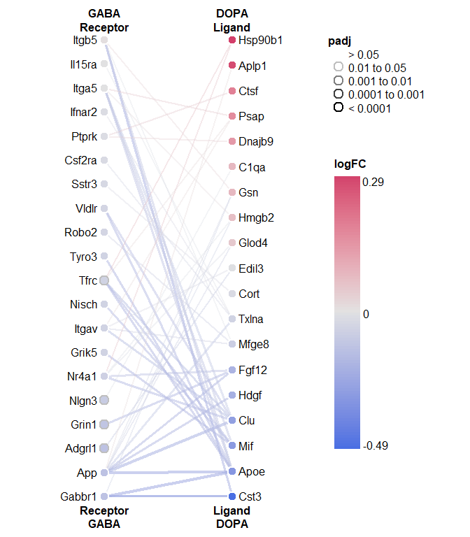

```r
PlotCCInx(INX=inx,
          cellTypeA="GABA",cellTypeB="DOPA",
          proteinTypeA="Receptor",proteinTypeB="Ligand",
          TopEdges=50)
# Also check out ViewCCInx(inx) for a Shiny viewer!
```

### Ranking nodes by expression magnitude

If no comparisons have been made experimentally, CCInx can use gene expression magnitude to rank nodes in its predicted interactions. Here we use a subset of data from the [developing murine cerebral cortex](https://github.com/BaderLab/MouseCortex) to demonstrate.

```r
load(system.file("DemoData/DemoExpr.RData",package="CCInx"))
show(e13cortex)
```

```
#>
#>
#>
#>
#>
#> class: SingleCellExperiment
#> dim: 843 323
#> metadata(0):
#> assays(1): logcounts
#> rownames(843): 1600012H06Rik 1700066M21Rik ... Zfyve27 Znrf3
#> rowData names(0):
#> colnames(323): TACTAGATGCTA AAATTCGTCGGT ... GCAAAATTTCAC
#>   TAAAACCTAATT
#> colData names(1): cellTypes
```

We can automatically generate the `GeneStatList` input for `BuildCCInx` from a `Seurat` or `SingleCellExperiment` object by using one of the functions from [scClustViz](https://baderlab.github.io/scClustViz/), repurposed here in the following function:

```r
gsl <- BuildGeneStatList(inD=e13cortex,
                         cl=colData(e13cortex)$cellTypes,
                         assayType="logcounts")
```

```
#> -- Calculating gene detection rate per cluster --
#> -- Calculating mean detected gene expression per cluster --
#> -- Calculating mean gene expression per cluster --
```

```r
lapply(gsl[1:3],head)
```

```
#> $ProjectionNeurons
#>                DetectRate MeanDetectGeneExpr MeanNormGeneExpr
#> 1600012H06Rik 0.034188034         0.96027540        -3.846653
#> 1700066M21Rik 0.042735043         0.60205847        -3.881925
#> 4931414P19Rik 0.034188034        -0.08063235        -4.823379
#> Abca1         0.017094017         1.26484824        -4.502413
#> Abhd15        0.008547009        -0.67777189        -6.893249
#> Acvr1         0.008547009         0.87558854        -5.736874
#>
#> $CorticalPrecursors
#>               DetectRate MeanDetectGeneExpr MeanNormGeneExpr
#> 1600012H06Rik 0.01904762        -0.11515394        -5.599577
#> 1700066M21Rik 0.03809524        -0.11207464        -4.709306
#> 4931414P19Rik 0.02857143         0.05859855        -4.931774
#> Abca7         0.04761905        -0.43947291        -4.715466
#> Abcc8         0.13333333        -0.04928220        -2.926440
#> Ackr3         0.04761905         0.05591052        -4.252934
#>
#> $IntermediateProgenitors
#>               DetectRate MeanDetectGeneExpr MeanNormGeneExpr
#> 1600012H06Rik 0.06930693          0.3824473        -3.423116
#> 1700066M21Rik 0.08910891          0.1107141        -3.335895
#> 4931414P19Rik 0.03960396         -0.6783537        -5.172877
#> Abca1         0.00990099         -2.0267104        -7.507622
#> Abca7         0.00990099         -1.6165331        -7.311758
#> Abcc8         0.07920792          0.2986867        -3.317917
```

```r
inx <- BuildCCInx(GeneStatList=gsl,
                  Species="mmusculus")
```

```
#> Scaling node weights per cell type...
#> Building node metadata...
#> Building edge list...
```

```r
head(inx$edges)
```

```
#>                                                                    nodeA
#> Abca1_ProjectionNeurons~Pltp_ProjectionNeurons   Abca1_ProjectionNeurons
#> Abca1_ProjectionNeurons~Slc1a5_ProjectionNeurons Abca1_ProjectionNeurons
#> Abca1_ProjectionNeurons~Slc7a1_ProjectionNeurons Abca1_ProjectionNeurons
#> Acvr1_ProjectionNeurons~Acvr1b_ProjectionNeurons Acvr1_ProjectionNeurons
#> Acvr1_ProjectionNeurons~Acvr2a_ProjectionNeurons Acvr1_ProjectionNeurons
#> Acvr1_ProjectionNeurons~Acvr2b_ProjectionNeurons Acvr1_ProjectionNeurons
#>                                                                     nodeB
#> Abca1_ProjectionNeurons~Pltp_ProjectionNeurons     Pltp_ProjectionNeurons
#> Abca1_ProjectionNeurons~Slc1a5_ProjectionNeurons Slc1a5_ProjectionNeurons
#> Abca1_ProjectionNeurons~Slc7a1_ProjectionNeurons Slc7a1_ProjectionNeurons
#> Acvr1_ProjectionNeurons~Acvr1b_ProjectionNeurons Acvr1b_ProjectionNeurons
#> Acvr1_ProjectionNeurons~Acvr2a_ProjectionNeurons Acvr2a_ProjectionNeurons
#> Acvr1_ProjectionNeurons~Acvr2b_ProjectionNeurons Acvr2b_ProjectionNeurons
#>                                                  edgeWeight
#> Abca1_ProjectionNeurons~Pltp_ProjectionNeurons    0.1713428
#> Abca1_ProjectionNeurons~Slc1a5_ProjectionNeurons  0.2671990
#> Abca1_ProjectionNeurons~Slc7a1_ProjectionNeurons  0.1981018
#> Acvr1_ProjectionNeurons~Acvr1b_ProjectionNeurons  0.3138731
#> Acvr1_ProjectionNeurons~Acvr2a_ProjectionNeurons  0.2667038
#> Acvr1_ProjectionNeurons~Acvr2b_ProjectionNeurons  0.3765668
```

```r
head(inx$nodes)
```

```
#>                                                            node
#> 1600012H06Rik_ProjectionNeurons 1600012H06Rik_ProjectionNeurons
#> 1700066M21Rik_ProjectionNeurons 1700066M21Rik_ProjectionNeurons
#> 4931414P19Rik_ProjectionNeurons 4931414P19Rik_ProjectionNeurons
#> Abca1_ProjectionNeurons                 Abca1_ProjectionNeurons
#> Abhd15_ProjectionNeurons               Abhd15_ProjectionNeurons
#> Acvr1_ProjectionNeurons                 Acvr1_ProjectionNeurons
#>                                          gene          cellType
#> 1600012H06Rik_ProjectionNeurons 1600012H06Rik ProjectionNeurons
#> 1700066M21Rik_ProjectionNeurons 1700066M21Rik ProjectionNeurons
#> 4931414P19Rik_ProjectionNeurons 4931414P19Rik ProjectionNeurons
#> Abca1_ProjectionNeurons                 Abca1 ProjectionNeurons
#> Abhd15_ProjectionNeurons               Abhd15 ProjectionNeurons
#> Acvr1_ProjectionNeurons                 Acvr1 ProjectionNeurons
#>                                 proteinType nodeWeight  DetectRate
#> 1600012H06Rik_ProjectionNeurons      Ligand 0.38054423 0.034188034
#> 1700066M21Rik_ProjectionNeurons      Ligand 0.37689638 0.042735043
#> 4931414P19Rik_ProjectionNeurons      Ligand 0.27952939 0.034188034
#> Abca1_ProjectionNeurons            Receptor 0.31272425 0.017094017
#> Abhd15_ProjectionNeurons             Ligand 0.06545941 0.008547009
#> Acvr1_ProjectionNeurons            Receptor 0.18505395 0.008547009
#>                                 MeanDetectGeneExpr MeanNormGeneExpr
#> 1600012H06Rik_ProjectionNeurons         0.96027540        -3.846653
#> 1700066M21Rik_ProjectionNeurons         0.60205847        -3.881925
#> 4931414P19Rik_ProjectionNeurons        -0.08063235        -4.823379
#> Abca1_ProjectionNeurons                 1.26484824        -4.502413
#> Abhd15_ProjectionNeurons               -0.67777189        -6.893249
#> Acvr1_ProjectionNeurons                 0.87558854        -5.736874
```

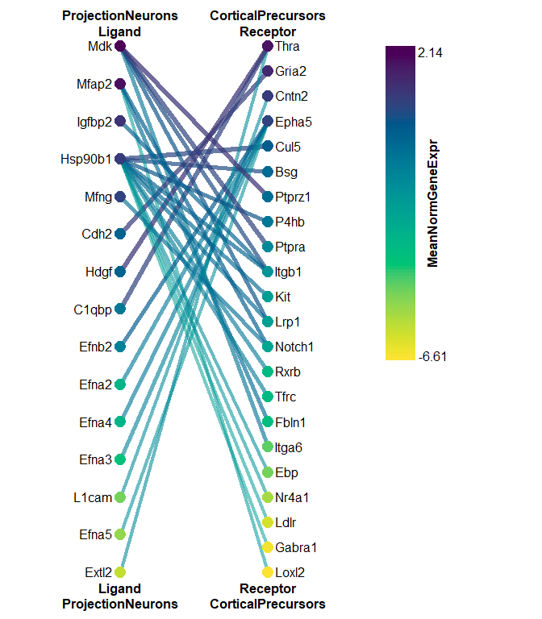

```r
PlotCCInx(INX=inx,
          cellTypeA="ProjectionNeurons",cellTypeB="CorticalPrecursors",
          proteinTypeA="Ligand",proteinTypeB="Receptor",
          GeneMagnitudeThreshold=.5)
# Also check out ViewCCInx(inx) for a Shiny viewer!
```